# FPCC2 - Laboratório 1

Thiago André Rego Chaves

25/03/2022

# Questões do Laboratório 1

```r
library(ggplot2)
library(scales)
require(tidyverse)
source("../code/lab1.R")
```

```
## here() starts at D:/Mestrado UFCG/FPCC2/fpcc2-lab1-thiagoarc
```

[output not shown]

[output cut: 25 more lines]

## Questão 1

- Calcule média e desvio padrão da idade e nível de interesse. As métricas contendos as métricas calculadas para idade e devem ser apresentadas de forma ordenada, da maior idade para a menor. Além de apresentar no relatório, os resultados devem ser salvos em um arquivo csv, que deve ser adicionado ao repositório.

```r
df_idade <- turma_fpcc2 %>% select(idade) %>%
  mutate(idade = as.integer(gsub("[a-z]|\\.", "", idade)))

md_idade <- mean(df_idade$idade)
dp_idade <- sd(df_idade$idade)

df_ni <- turma_fpcc2 %>% select(conf_sumarios) %>% group_by(conf_sumarios) %>% summarise(nivel = n())
md_nivel <- mean(df_ni$nivel)
dp_nivel <- sd(df_ni$nivel)

fpcc2_campos <- c("Media Idade","Media NI", "DP Idade", "DP NI")
fpcc2_valores <- c(md_idade,md_nivel,dp_idade,dp_nivel)

fpcc2.data <- data.frame(fpcc2_campos, fpcc2_valores)

print(fpcc2.data)
```

```
##   fpcc2_campos fpcc2_valores
## 1  Media Idade     29.666667
## 2     Media NI      4.800000
## 3     DP Idade      5.798551
## 4        DP NI      1.483240
```

```r
write.csv(fpcc2.data,"D:/Mestrado UFCG/FPCC2/fpcc2-lab1-thiagoarc/csv/questao1.csv")
```

## Questão 2

- Qual o curso com maior valor médio de idade? Discutir os resultados com base nos dados disponíveis em termos de representatividade.

```r
q1 <- turma_fpcc2 %>%
select(tipo_curso, idade) %>%
mutate(idade_int = as.integer(gsub("[a-z]|\\.", "", idade))) %>%
group_by(tipo_curso) %>%
summarise(mean(idade_int))

print(q1)
```

```
## # A tibble: 2 x 2
##   tipo_curso `mean(idade_int)`
##   <chr>                  <dbl>
## 1 Doutorado               35.7
## 2 Mestrado                28.8
```

```r
print("O curso com maior valor médio de idade é: ")
```

```
## [1] "O curso com maior valor médio de idade é: "
```

```r
print(q1 %>% top_n(1))
```

```
## # A tibble: 1 x 2
##   tipo_curso `mean(idade_int)`
##   <chr>                  <dbl>
## 1 Doutorado               35.7
```

## Questão 3

- Crie um gráfico que mostra a idade média para cada curso. Apresente o gráfico e discuta os resultados no relatório. O gráfico também deve ser salvo em uma imagem no formato png, que deve ser adicionada ao repositório.

```r
q1 <- turma_fpcc2 %>%
select(tipo_curso, idade) %>%
mutate(idade_int = as.integer(gsub("[a-z]|\\.", "", idade))) %>%
group_by(tipo_curso) %>%
summarise(media = mean(idade_int))

print(q1)
```

```
## # A tibble: 2 x 2
##   tipo_curso media
##   <chr>      <dbl>
## 1 Doutorado   35.7
## 2 Mestrado    28.8
```

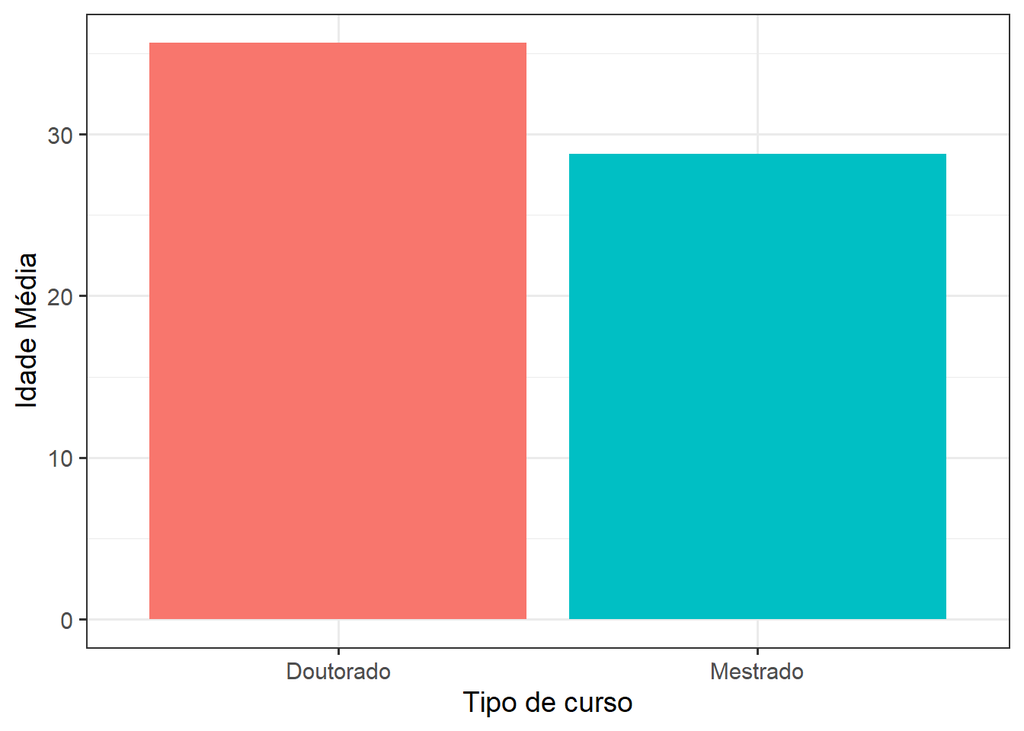

```r
graph3 <- ggplot(q1, aes(tipo_curso, media, fill = tipo_curso)) +
  geom_bar(stat = "identity") +
  xlab("Tipo de curso") +
  ylab("Idade Média") +
  theme_bw(base_size = 14) +
  theme(legend.position = "None")

print(graph3)
```

```r
ggsave(graph3, filename='D:/Mestrado UFCG/FPCC2/fpcc2-lab1-thiagoarc/images/questao3.png', dpi = 400, type='cairo', units='in')
```

## Questão 4

- Crie um gráfico que mostra o percentual de alunos para cada estado de origem. Apresente o gráfico e discuta os resultados no relatório. O gráfico também deve ser salvo em uma imagem no formato png, que deve ser adicionada ao repositório.

```r
q4 <- turma_fpcc2 %>% select(uf) %>%
  mutate(uf = case_when(
    uf == "Opção 1" ~ "NA",
    uf == "Paraiba" ~ "PB",
    uf == "Paraíba" ~ "PB",
    uf == "PB (Campina Grande)" ~ "PB",
    uf == "Acre" ~ "AC",
    uf == "Alagoas" ~ "AL",
    uf == "Pernambuco, mas moro em Campina Grande há mais de 20 anos" ~ "PE",
    TRUE ~ uf
  )) %>%
  filter(!is.na(uf)) %>%
  count(uf) %>%
  arrange(-n, uf)

print(q4)
```

```
## # A tibble: 6 x 2
##   uf        n
##   <chr> <int>
## 1 PB       14
## 2 NA        5
## 3 AC        2
## 4 AL        1
## 5 PE        1
## 6 RJ        1
```

```r
q4 <- q4 %>%
  mutate(perc = n/sum(n))

print(q4)
```

```
## # A tibble: 6 x 3
##   uf        n   perc
##   <chr> <int>  <dbl>
## 1 PB       14 0.583
## 2 NA        5 0.208
## 3 AC        2 0.0833
## 4 AL        1 0.0417
## 5 PE        1 0.0417
## 6 RJ        1 0.0417
```

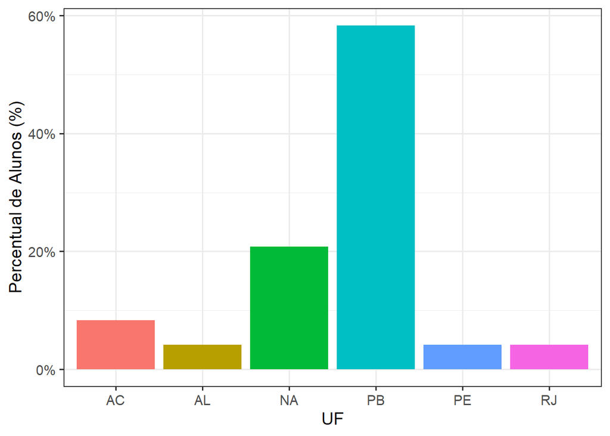

```r
graph4 <- ggplot(q4, aes(uf, perc, fill = uf)) +
  geom_bar(stat = "identity") +
  xlab("UF") +
  ylab("Percentual de Alunos (%)") +
  theme_bw(base_size = 14) +
  theme(legend.position = "None") +
  scale_y_continuous(labels = percent)

print(graph4)
```

```r
ggsave(graph4, filename='D:/Mestrado UFCG/FPCC2/fpcc2-lab1-thiagoarc/images/questao4.png', dpi = 400, type='cairo', units='in')
```

## Questão 5

- Compare a média de idade geral com a média de idade dos top-5 e dos bottom-5. Além de apresentar e discutir os resultados no relatório, salvar em uma tabela (dataframe) com as médias em questão.

```r
df_idade <- turma_fpcc2 %>% select(idade) %>%
  mutate(idade = as.integer(gsub("[a-z]|\\.", "", idade)))
md <- mean(df_idade$idade)



print('A média geral de idade é: ')
```

```
## [1] "A média geral de idade é: "
```

```r
print(md)
```

```
## [1] 29.66667
```

```r
q5 <- turma_fpcc2 %>%
select(idade) %>%
mutate(idade = as.integer(gsub("[a-z]|\\.", "", idade)))

print(' A média do TOP-5 é: ')
```

```
## [1] " A média do TOP-5 é: "
```

```r
qt5 <- q5 %>%
  arrange(desc(idade)) %>%
  slice(1:5)

print(qt5)
```

```
## # A tibble: 5 x 1
##   idade
##   <int>
## 1    39
## 2    39
## 3    38
## 4    38
## 5    37
```

```r
mtd <- mean(qt5$idade)
print(mtd)
```

```
## [1] 38.2
```

```r
print(' A média do BOTTOM-5 é: ')
```

```
## [1] " A média do BOTTOM-5 é: "
```

```r
qb5 <- q5 %>%
  arrange(idade) %>%
  slice(1:5)

print(qb5)
```

```
## # A tibble: 5 x 1
##   idade
##   <int>
## 1    22
## 2    22
## 3    23
## 4    24
## 5    25
```

```r
mbd <- mean(qb5$idade)
print(mbd)
```

```
## [1] 23.2
```

```r
df_idade_q5 <- data.frame(md, mtd, mbd)


# renomeando colunas
colnames <- c("Média Geral de Idades", "Média de Idades TOP-5", "Média de Idades BOTTOM-5")
colnames(df_idade_q5) <- colnames

print(df_idade_q5)
```

```
##   Média Geral de Idades Média de Idades TOP-5 Média de Idades BOTTOM-5
## 1              29.66667                  38.2                     23.2
```